# STAT760_Homework2

Natalie Bladis, Johnny Lomas

2023-02-08

## Exercise 1. (ESL Ex. 3.12) – 3 pts

Show that the ridge regression estimates can be obtained by ordinary least squares regression on an augmented data set. We augment the centered matrix X with p additional rows $\sqrt{\lambda{I}}$, and augment y with p zeros. By introducing artificial data having response value zero, the fitting procedure is forced to shrink the coefficients toward zero. This is related to the idea of hints due to Abu-Mostafa (1995), where model constraints are implemented by adding artificial data examples that satisfy them.

## Solution:

Let $X^*=\begin{bmatrix}X \\\sqrt{\lambda}I_p\end{bmatrix}$ and $y^* = \begin{bmatrix}y \\0_p\end{bmatrix}$ where $I_p$ is a $p \times p$ identify matrix and $0_p$ is a $p \times 1$ vector of zeros.

Then

$$\begin{aligned}
X^{*T}X^* &= \begin{bmatrix}X \sqrt{\lambda}I_p\end{bmatrix}
\begin{bmatrix}X \\\sqrt{\lambda}I_p\end{bmatrix} \\
&= X^TX+\lambda I_p
\end{aligned}$$
and
$$\begin{aligned}
X^{*T}y^* &= \begin{bmatrix}X \sqrt{\lambda}I_p\end{bmatrix}
\begin{bmatrix} y \\0_p\end{bmatrix} \\
&= X^Ty+ \sqrt\lambda I_p 0_p \\
&= X^Ty
\end{aligned}$$
Therefore,
$$\begin{aligned}
\hat{\beta}_{new} &= (X^{*T}X^*)^{-1}X^{*T}y^* \\
&= (X^Ty+ \lambda I_p)^{-1} X^Ty
\end{aligned}$$
Which is the $\hat{\beta}$ estiamte for ridge regression.

## Exercise 2. (Programming) – 12 pts

Use prostate cancer example to reproduce the following figure. The Prostate data are available from the book website https://www.hastie.su.domains/ElemStatLearn/.

```r
setwd("/Users/ntb3/Documents/STAT_760_Statistical_Learning/Statistical_Learning/HW2")
#setwd("/Users/jslomas/Box/STAT_760/Statistical_Learning/HW2")
library(dplyr)
```

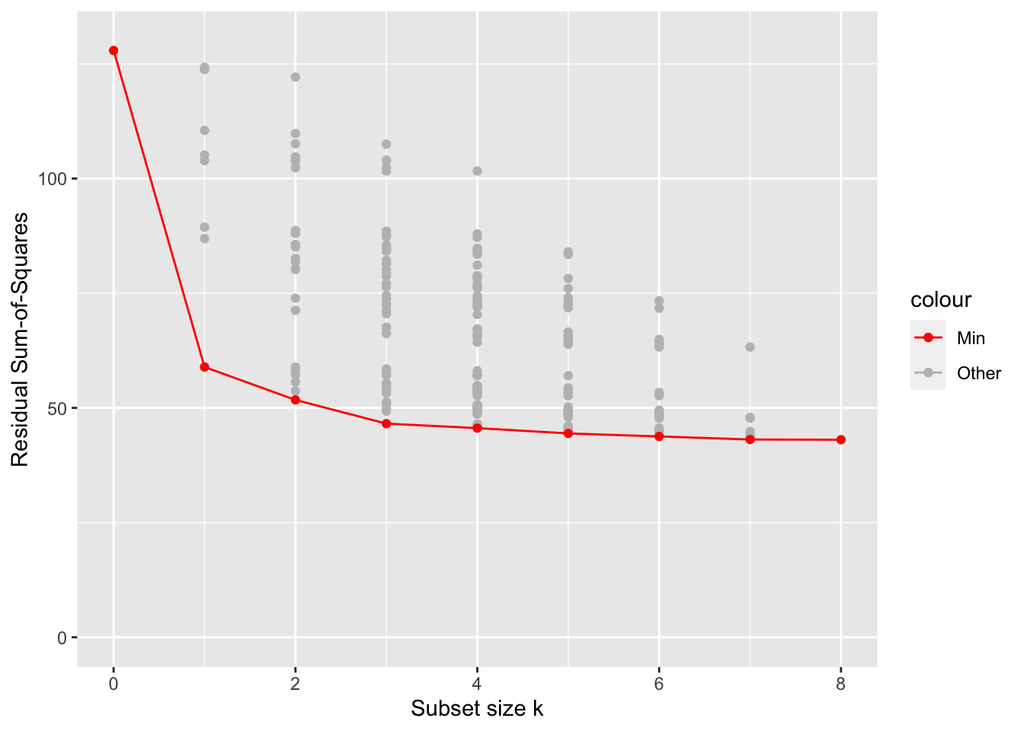

```r
library(ggplot2)
library(data.table)
# Input (x): Augmented data matrix
# Input (y): Response vector
# Return: Fitted parameter vector (beta)
fitLeastSquares <- function(x, y){
   beta = solve(t(x) %*% x) %*% t(x) %*% y
   return(beta)
}

predictLeastSquares <- function(x, beta) {
  y_hat <- x %*% beta
  return(y_hat)
}

# Input (y)    : Original response vector
# Input (y_hat): Predicted response vector
# Return       : RSS value, scalar
computeRSS <- function(y, y_hat){
  rss <- t(y-y_hat) %*% (y-y_hat)
  return(rss)
}

prostate <- read.delim("prostate.tsv")
response <- as.matrix(prostate %>% select(lpsa))
data <- prostate %>% select(lcavol:pgg45)

plot_data <- data.frame()
# TODO: fit null case and add to plotting dataframe
null_rss <- sum((response - mean(response))^2)
plot_data <- rbind(plot_data, c(null_rss, 0))

for (feat in 1:ncol(data)){
  sets <- combn(1:ncol(data), feat)
  for (set in 1:ncol(sets)){
    data_subset <- data %>% select(sets[,set])
    data_subset <- cbind(rep(1, nrow(data)), data_subset)
    data_subset <- as.matrix(data_subset)

    beta_hat <- fitLeastSquares(data_subset, response)
    y_hat <- predictLeastSquares(data_subset, beta_hat)
    rss <- computeRSS(response, y_hat)

    # min_rss_vector <- c()
    # min_rss <- min(rss)
    #
    # if (rss == min_rss) {
    # min_rss_vector == 1
    #   } else {
    #   min_rss_vector == 0
    #   }

    plot_data <- rbind(plot_data, c(rss, feat))
  }

}

colnames(plot_data) <- c("RSS", "K")

plot_data <- as.data.table(plot_data)
mins <- plot_data[ , .SD[which.min(RSS)], by = K]
plot_data <- cbind(plot_data, mins = plot_data$RSS %in% mins$RSS) %>%
  mutate(minID = ifelse(mins == TRUE, "Min", "Other")) %>%
  mutate(minID = relevel(factor(minID), ref = "Other")) %>%
  mutate(minID = factor(minID, levels = rev(levels(minID))))


ggplot(plot_data, aes(x=K, y=RSS, group = minID)) +
  geom_point(data = plot_data[plot_data$mins == F], aes(color = "Other")) +
  geom_point(data = plot_data[plot_data$mins == T], aes(color = "Min")) +
  geom_line(data = plot_data[plot_data$mins == T], aes(color = "Min")) +
  ylim(c(0,130)) +
  ylab("Residual Sum-of-Squares") +
  xlab("Subset size k") +
  scale_color_manual(values = c("red", "gray"))
```

## Exercise 3. (Programming) – 15 pts

Use prostate cancer example to produce a similar figure below (also Figure 3.7 in ESL), where the x-axis is the parameter λinstead of degrees of freedom. The estimates of prediction errors are obtained by 10-fold cross-validation. The Prostate data are available from the book website https://www.hastie.su.domains/ElemStatLearn/.

1)Write a function to do ridge reg

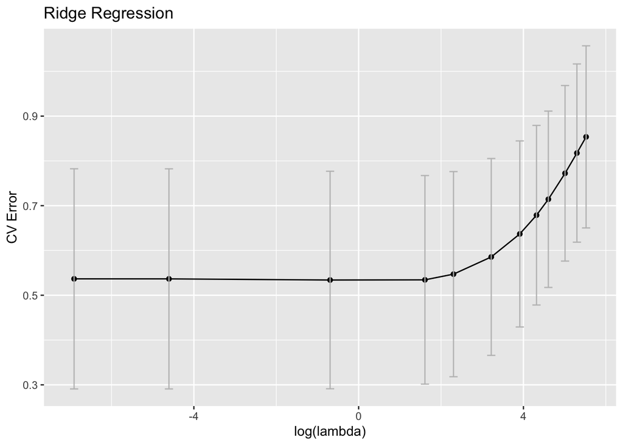

```r
library(dplyr)


count = 1
sets = c()
for (i in 1:9){
  sets <- append(sets, rep(count, 10))
  count = count + 1
}
set.seed(1)
sets <- append(sets, rep(10, 7))
prostate <- read.delim("prostate.tsv") %>%
  select(lcavol:lpsa) %>%
  cbind(sort = runif(nrow(prostate), 0, 1)) %>%
  arrange(sort) %>%
  select(lcavol:lpsa) %>%
  cbind(sets = sets)

prostate <- as.data.frame(prostate)
prostate <- cbind(intercept = rep(1, nrow(prostate)), prostate)


# Input (x): Augmented data matrix
# Input (y): Response vector
# Input (l): lambda value
# Input (I)
# Return: Fitted parameter vector (beta)

fitRidgeRegression <- function(x, y, l){
   I = as.matrix(diag(ncol(x)))
   I[1,1] = 0
   beta_ridge = solve((t(x) %*% x) + l*I) %*% t(x) %*% y
   return(beta_ridge)
}

predictRidgeReg <- function(x, beta_ridge) {
  y_hat <- x %*% beta_ridge
  return(y_hat)
}


CV_error <- data.frame()

lambda <- c(0.001, 0.01, 0.5, 5,10,25,50, 75, 100,150, 200, 250)
#lambda <- log(lambda)
#lambda <-1/lambda

for (l in lambda){
  errors <- c()
  for (test in 1:10){
    train_set <- prostate %>% filter(sets != test)
    test_set <- prostate %>% filter(sets == test)
    x_train <- as.matrix(train_set %>% select(intercept:pgg45)) #%>% scale(T,F)
    y_train <- as.matrix(train_set %>% select(lpsa))

    x_test <- as.matrix(test_set %>% select(intercept:pgg45)) #%>% scale(T,T)
    y_test <- as.matrix(test_set %>% select(lpsa))

    beta_ridge_response <- fitRidgeRegression(x_train, y_train, l)
    ridge_reg_hat <- predictRidgeReg(x_test, beta_ridge_response)



    mse <- mean((y_test-ridge_reg_hat)^2)
    errors <- append(errors, mse)

  }
  mse_mean <- mean(errors)
  mse_min <- min(errors)
  mse_max <- max(errors)
  mse_sd_plus <- mean(errors) + sd(errors)
  mse_sd_minus <- mean(errors) - sd(errors)


  CV_error <- rbind(CV_error, c(l, mse_mean, mse_min, mse_max, mse_sd_minus, mse_sd_plus )) # to change x-axis to df make first input 1/l (d_i^2)/(d_i^2-lambda)
}

colnames(CV_error) <- c("lambda", "CV", "Min_MSE", "Max_MSE", "minus_sd", "plus_sd")
CV_error <- CV_error %>% mutate(log_lambda = log(lambda)) #addlog back in here



ggplot(CV_error, aes(x=log_lambda, y=CV)) +
  geom_point() +
  geom_line() +
  #geom_errorbar(aes(x=log_lambda, ymin=Min_MSE, ymax=Max_MSE), width=0.2, colour="grey", alpha=0.9, size=0.5) +
  geom_errorbar(aes(x=log_lambda, ymin=minus_sd, ymax=plus_sd), width=0.2, colour="grey", alpha=0.9, size=0.5) +
  #ylim(c(0.25,1.25)) +
  #xlim(c(-6,7)) +
  ylab("CV Error") +
  xlab("log(lambda)") +
  ggtitle("Ridge Regression")
```